# The Interview Attendance Problem

Jake Close and Peter Kaplan

11/21/2017

## Context

The data pertains to the recruitment industry in India for the years 2014-2016 and deals with candidate interview attendance for various clients. When candidates don’t appear for interviews, valuable time and resources are lost.

## Business Value

If we are able to predict which canidates may not appear, the company and hr could save money and time. Also, understanding which factors may cause a person to not appear could be valuable when trying to improve attendenance rates.

We believe that we can determine with a degree of accuracy who will show or not show for an interview and so the businesses can only book those that will show up.

# Import Libraries and Read Data

```r
library(dummies)
```

```r
library(class)
library(gmodels)
library(ggplot2)
library(dplyr)
library(C50)
interviews <- read.csv("Interview.csv")
```

# Data Cleaning

It appears the are extra columns read that are completely full of NA’s. Lets drop these.

```r
interviews <- interviews[, 1:23]
```

Lets rename the variables to make them more readable.

```r
names <- c("Date", "Client", "Industry", "Location", "Position", "Skillset", "Interview_Type", "ID", "Gender", "Candidate_Loc", "Job_Location", "Venue", "Native_Loc", "Permission", "Hope", "3_hour_call", "Alt_Number", "Resume_Printout", "Clarify_Venue", "Share_Letter", "Expected", "Attendance", "Marital_Status")
colnames(interviews) <- names
```

Next, lets explore which variables may need to be cleaned.

We check the intial structure of the dataset in order to do some data cleaning and exploration

```r
str(interviews)
```

```
## 'data.frame':    1233 obs. of  23 variables:
##  $ Date           : Factor w/ 96 levels "02.09.2016","02.12.2015",..: 26 26 26 26 26 26 26 26 26 26 ...
##  $ Client         : Factor w/ 15 levels "ANZ","Aon Hewitt",..: 8 8 8 8 8 2 2 2 2 2 ...
##  $ Industry       : Factor w/ 7 levels "BFSI","Electronics",..: 6 6 6 6 6 5 5 5 5 5 ...
##  $ Location       : Factor w/ 11 levels "- Cochin- ","Bangalore",..: 4 4 4 4 4 8 8 8 8 8 ...
##  $ Position       : Factor w/ 7 levels "AML","Dot Net",..: 4 4 4 4 4 6 6 6 6 6 ...
##  $ Skillset       : Factor w/ 92 levels "- SAPBO, Informatica",..: 74 74 74 74 74 74 74 74 74 74 ...
##  $ Interview_Type : Factor w/ 6 levels "Sceduled walkin",..: 4 4 4 4 4 4 4 4 4 4 ...
##  $ ID             : Factor w/ 1233 levels "Candidate 1",..: 1 346 457 568 679 790 901 1012 1123 2 ...
##  $ Gender         : Factor w/ 2 levels "Female","Male": 2 2 2 2 2 2 2 1 2 1 ...
##  $ Candidate_Loc  : Factor w/ 10 levels "- Cochin- ","Bangalore",..: 4 4 4 4 4 8 8 8 8 8 ...
##  $ Job_Location   : Factor w/ 7 levels "- Cochin- ","Bangalore",..: 5 2 3 3 2 4 4 4 4 4 ...
##  $ Venue          : Factor w/ 7 levels "- Cochin- ","Bangalore",..: 5 5 5 5 5 4 4 4 4 4 ...
##  $ Native_Loc     : Factor w/ 46 levels "- Cochin- ","Agra",..: 23 40 12 12 12 21 21 32 18 18 ...
##  $ Permission     : Factor w/ 7 levels "Na","No","NO",..: 6 6 NA 6 6 6 6 6 6 6 ...
##  $ Hope           : Factor w/ 7 levels "cant Say","Na",..: 7 7 2 7 7 7 7 7 7 7 ...
##  $ 3_hour_call    : Factor w/ 5 levels "Na","No","No Dont",..: 5 5 NA 2 5 5 5 5 5 5 ...
##  $ Alt_Number     : Factor w/ 6 levels "na","Na","No",..: 6 6 NA 6 3 6 6 6 6 6 ...
##  $ Resume_Printout: Factor w/ 8 levels "na","Na","No",..: 8 8 NA 3 8 8 8 8 8 8 ...
##  $ Clarify_Venue  : Factor w/ 7 levels "na","Na","no",..: 7 7 NA 7 7 7 7 7 7 7 ...
##  $ Share_Letter   : Factor w/ 12 levels "Havent Checked",..: 11 11 NA 11 11 11 11 11 11 11 ...
##  $ Expected       : Factor w/ 7 levels "10.30 Am","11:00 AM",..: 7 7 5 5 5 7 7 7 7 7 ...
##  $ Attendance     : Factor w/ 8 levels "no","No","NO",..: 2 2 2 2 2 7 7 7 7 2 ...
##  $ Marital_Status : Factor w/ 2 levels "Married","Single": 2 2 2 2 1 2 2 2 2 2 ...
```

From the intial structure, it appears that all of the variables are factor based. Each variable has a large number of factors aswell. Lets explore these factors to make sure that there are no duplicates, similar values or NA.

It appears that most of the columns have 1 NA. Lets see which if this is the last value?

```r
tail(interviews)
```

```
##            Date Client        Industry Location Position
## 1228 07.05.2016 Pfizer Pharmaceuticals  Chennai    Niche
## 1229 07.05.2016 Pfizer Pharmaceuticals  Chennai    Niche
## 1230 07.05.2016 Pfizer Pharmaceuticals  Chennai    Niche
## 1231 06.05.2016 Pfizer Pharmaceuticals  Chennai    Niche
## 1232 06.05.2016 Pfizer Pharmaceuticals  Chennai    Niche
## 1233 06.05.2016 Pfizer Pharmaceuticals  Chennai    Niche
##                Skillset Interview_Type             ID Gender Candidate_Loc
## 1228     Licensing – RA     Scheduled  Candidate 1228   Male       Chennai
## 1229 generic drugs – RA     Scheduled  Candidate 1229   Male       Chennai
## 1230       Biosimiliars     Scheduled  Candidate 1230   Male       Chennai
## 1231       Biosimiliars     Scheduled  Candidate 1231   Male       Chennai
## 1232 generic drugs – RA     Scheduled  Candidate 1232   Male       Chennai
## 1233 generic drugs – RA     Scheduled  Candidate 1233 Female       Chennai
##      Job_Location   Venue Native_Loc Permission Hope 3_hour_call
```

[output cut: 20 more lines]

```r
interviews <- interviews[1:1232, ]
```

# ID

For Classifation, we should drop Candidate ID since it is unique for each row.

```r
interviews <- interviews[, -8]
```

# Predictor Variable Attendance

Lets explore our predictor variable, observed attendance: Again, we find this is dirty, so lets convert to lowercase first and trim.

```r
interviews$Attendance <- trimws(interviews$Attendance)
interviews$Attendance <- tolower(interviews$Attendance)
interviews$Attendance <- as.factor(interviews$Attendance)

round(prop.table(table(interviews$Attendance)) * 100, 1)
```

```
##
##   no  yes
## 36.5 63.5
```

We find about a 1/3 to 2/3 split of people that have attended. This will serve as a benchmark for our predictions.

# Industry

```
## [1] "BFSI"            "Electronics"     "IT"              "Pharmaceuticals"
## [5] "Telecom"
```

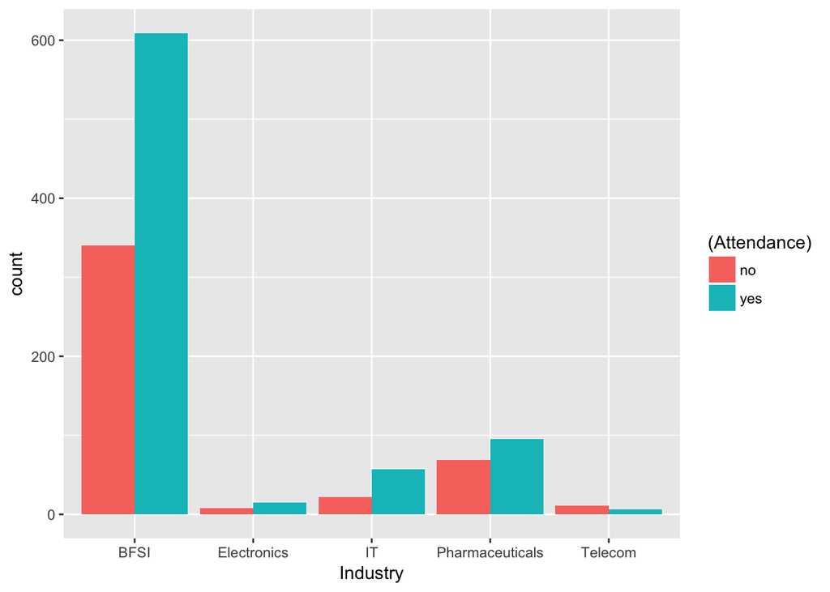

When comparing Attendance to Industry type of interview, we find that each group has a relatively similar proportion of attendance. BFSI is the most popular Industry. Lastly, Telecom and Pharmaceuticals have worst rates of attendence.

# Location

It looks like Chennai is spelt differently for four different factors, lets combine these. Also, Gurgaon is split with an extra r. We can fix this by converting all locations to lower

Lets also fix the misspelling of the city Gurgaon.

# Position

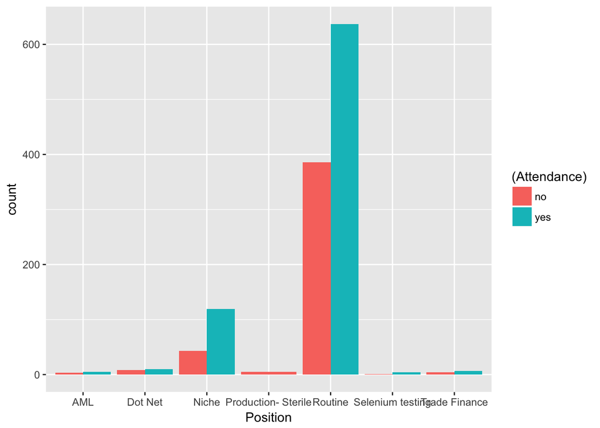

# Gender

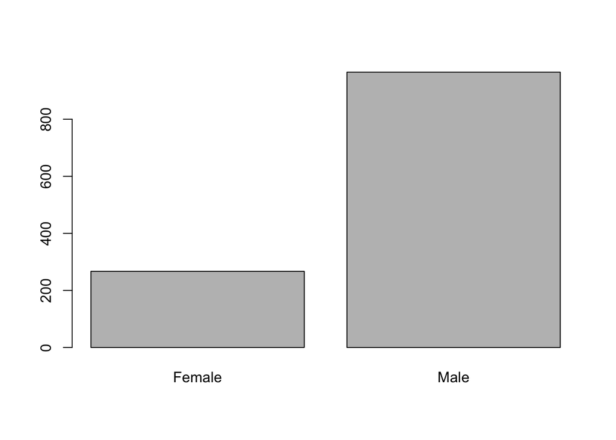

We see that the data is much more male dominated.

[figure not shown]

This graph is for “Hope that there will be no unscheduled meetings” and we can see that in a high majority of the time there is a belief there will be no interruptions.

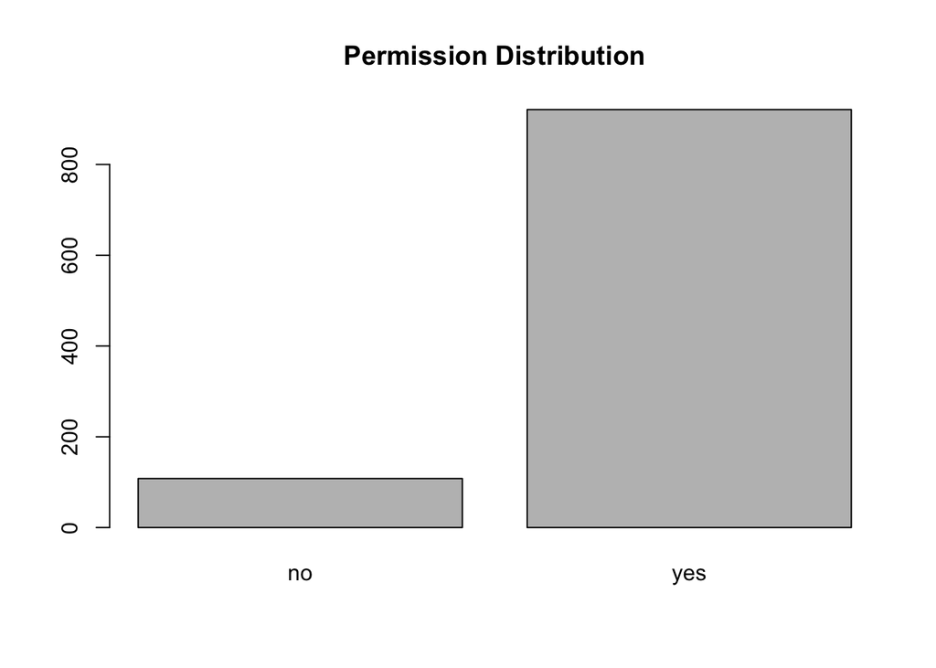

This graph is for “Permission to start at the required time” and the graph shows the results as a majority yes. This means that if they get the job they can start right away.

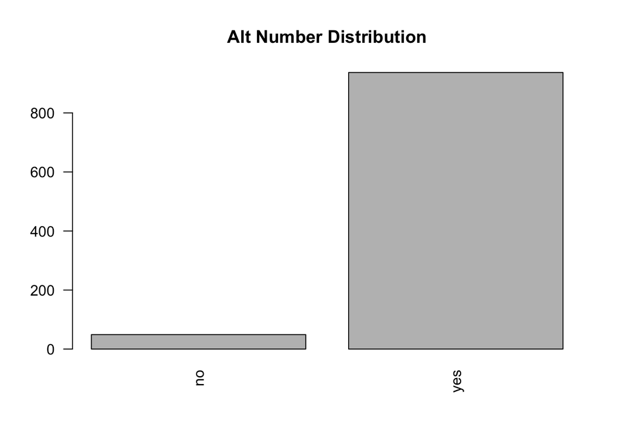

This graph displays if the candidate has given an alternate number to be reached by. A high majority of the interviewees gave an alternate number.

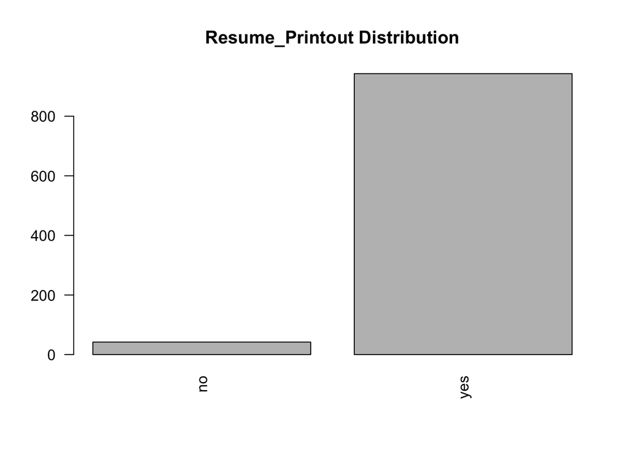

This graph shows if the candidate has recently printed out his or her resume. Most of them have.

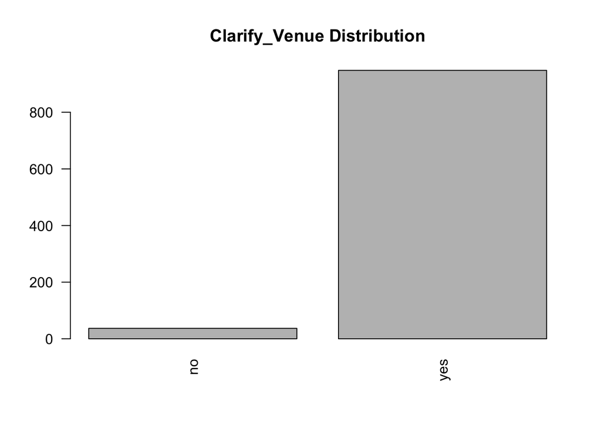

This graph shows that most of the candidates did confirm where his or her interview location was before the interview was scheduled.

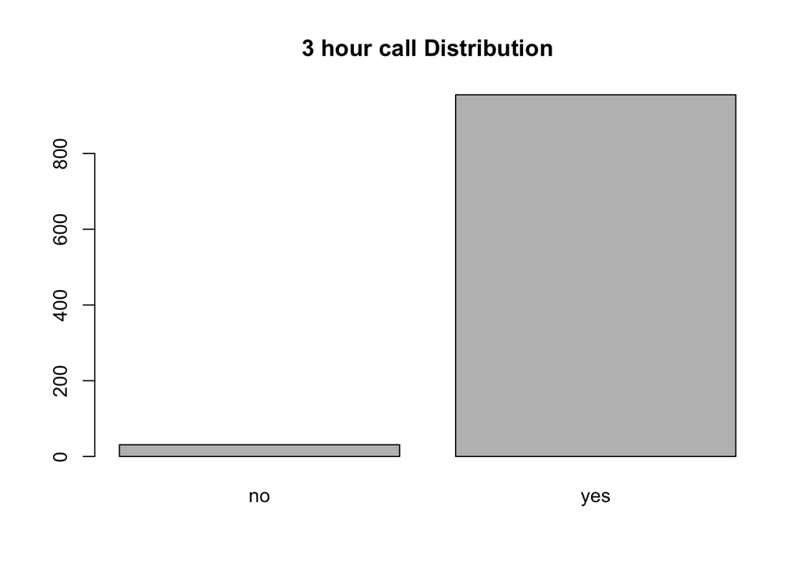

Most of the candidates agreed to a 3 hour “warning call” to alert them that the interview will take place in 3 hours.

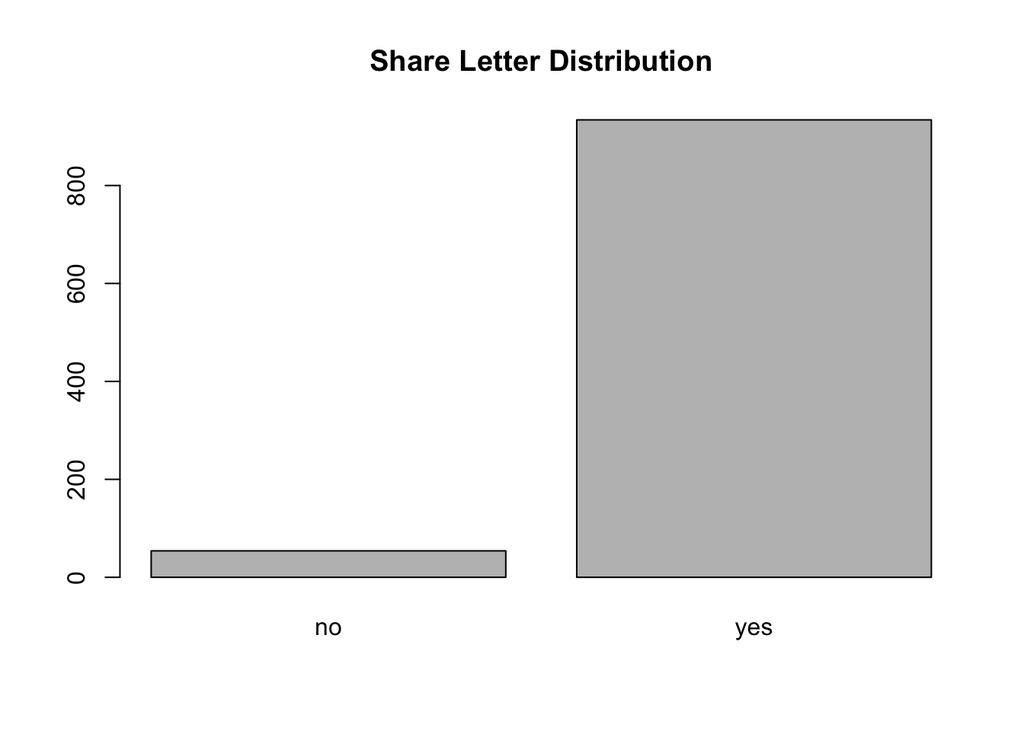

A call letter is given to the candidate and it lets them know the information about the scheduled interview. Most of the candidates did receive the call letter and were in posession of it.

## Native Location

Refers to the candidate’s hometown.

```
##
##    - Cochin-           Agra     Ahmedabad     Allahabad         Ambur
##             5             1             5            20             2
##     Anantapur         Baddi     Bangalore       Belgaum  Bhubaneshwar
##             1             1           151             1             1
##    Chandigarh       Chennai       Chitoor        Cochin    Coimbatore
##             5           595             6            24            21
##       Cuttack         Delhi    Delhi /NCR      Faizabad     Ghaziabad
##            25             4             2             1             1
##       Gurgaon        Hissar         Hosur     Hyderabad        Kanpur
##            26             1             3           172             1
##       Kolkata       Kurnool       Lucknow        Mumbai        Mysore
##            13             1             1             7             1
##     Nagercoil         Noida        Panjim         Patna   Pondicherry
##            16            17             1             2             5
##          Pune         Salem       Tanjore      Tirupati        Trichy
##            22             3             1             4            13
##    Trivandrum     Tuticorin       Vellore    Vijayawada Visakapatinam
##            14             1            12             4            16
##      Warangal
##             3
```

The majority of locations are <25, with the major candidate locations coming from Chennai, Hyderbad, and Bangalore.

## Job Location

```
##
##    - Cochin-      Bangalore       Chennai       Gurgaon         Hosur
##             9           259           892            35             1
##         Noida Visakapatinam
##            15            21
```

# Distance function

Lets see if we can add to this data and add another data point to make our prediction better. We can use the Google Maps API in order to get the distance between where the candidate’s location is vs where the interview location is to see if they need to travel to the interview. This could be a good indicator as if a candidate is further away they might not want to go to the interview.

```r
library("gmapsdistance")
```

```r
#Only want to make the Google Maps API calls once so this was run then written to csv.
#Lets loop through and make an API call for each city to find distances and create a lookup table.
if (FALSE){
  set.api.key("") #Key hidden

  distinct = interviews %>% distinct(Native_Loc)
  cities = interviews %>% distinct(Job_Location)

  cities <- cities[,colSums(is.na(cities))<nrow(cities)]

  cities <- cities[!is.na(cities)]
  distinct <- distinct[is.na(cities)]
  distinct <- distinct[-1]

  distinct$"Hosur" <- 0
  distinct$"Bangalore" <- 0
  distinct$"Chennai" <- 0
  distinct$"Guraonr" <- 0
  distinct$"Visakapatinam" <- 0
  distinct$"Cochib" <- 0
  distinct$"Noida" <- 0

  for(j in 1:ncol(distinct) -1) {
    for(i in 1:nrow(distinct)) {
        results <- gmapsdistance(origin = as.character(distinct[i,1]),
                            destination =as.character(cities[j]),
                            mode = "driving")
        distinct[i,j+1] = results$Distance
    }
  }

  write.csv(distinct, 'distances.csv')
}

# Lets read in the lookup table that we created earlier. Need to do some specific cleaning on it for NAs and Misspellings that are left.
distances_lookup_table <- read.csv("distances.csv")
distances_lookup_table <- distances_lookup_table[-6,]
names(distances_lookup_table)[5] <- "Gurgaon"
interviews$Location[interviews$Location == "Gurgaonr"] <- "Gurgaon"
interviews$Location[469] <- "Gurgaon"


# Function that returns the distance in the lookup table
lookup <- function(distances_lookup_table, start, end) {

  # If the start == end, distance is 0
  if(tolower(as.character(start)) == tolower(as.character(end))){
    return(0)
  }

  dist <- distances_lookup_table[tolower(distances_lookup_table$Native_Loc) == as.character(start), as.character(end)]

  # If the lookup table returns nothing then set it to be -1 otherwise return the distance
  if (is.null(dist)){
    return (-1)
  } else {
    return(dist)
  }

}

# Lets set the distance column in the interveiw section
for(i in 1:nrow(interviews)){
  val <-lookup(distances_lookup_table, tolower(interviews$Location[i]), sapply((as.character(interviews$Venue[i])),function(x) paste(toupper(substr(x,1,1)),substr(x,2,nchar(x)),sep="")))

  interviews$Distance[i] <- val
}
```

# Interview Type

There are three different types: Walkin drives, Scheduled, and scheduled walkin

```r
table(interviews$Interview_Type)
```

```
##
##   Sceduled walkin        Scheduled  Scheduled Walk In  Scheduled Walkin
##                 1               370               456               189
##            Walkin           Walkin
##               189                27
```

It appears the scheduled walkin is described in three ways. Lets combine these.

Most of the interviews are Scheduled Walk-ins with scheduled and Walk-in following.

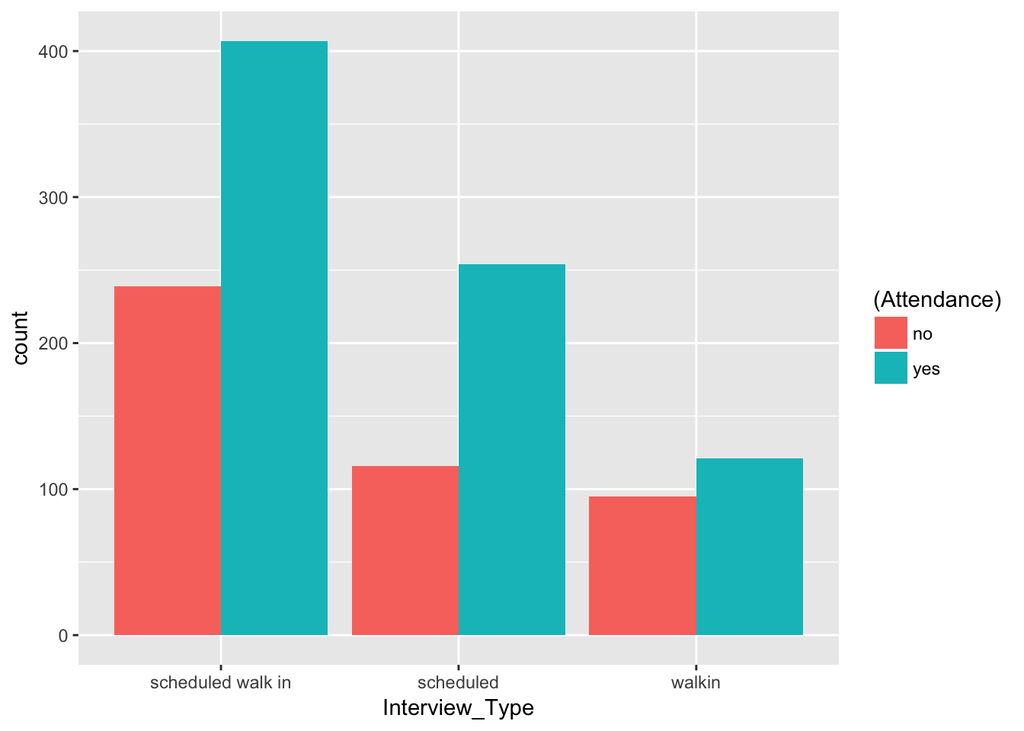

This graph shows that just walkins have the lowest rate of attendence compared to scheduled and scheduled walk-in,

# Expected

Lets clean up expected

```r
table(interviews$Expected)
```

```
##
##  10.30 Am  11:00 AM        No        NO Uncertain       yes       Yes
##         1         1        59        34       249         1       882
```

Lets convert 10:30 am and 11:00 am to Yes

We can see that most of the candidates are excepted to show up. There is also a high level of uncertainty. Hopefully we can shed some light on the uncertainty.

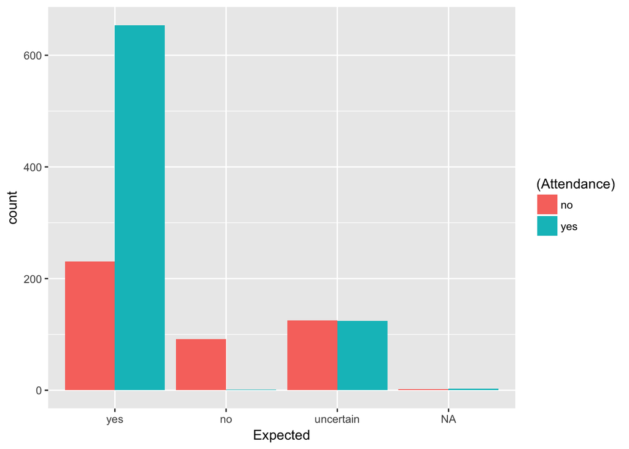

This graph shows that if a person is not expected to show they almost never do. If they are expected there is still a chance that they don’t show. Finally, if it is uncertain that the candidate will show there is about a 50/50 percent chance that they will attend the interview.

# Client

```r
table(interviews$Client)
```

```
##
##                             ANZ                      Aon Hewitt
##                              22                              28
##              Aon hewitt Gurgaon                     Astrazeneca
##                               2                              15
##                        Barclays                     Flextronics
##                               5                              23
##                          Hewitt                         Hospira
##                              20                              75
##                          Pfizer                         Prodapt
##                              74                              17
##         Standard Chartered Bank Standard Chartered Bank Chennai
##                             904                              17
##                             UST                    Williams Lea
##                              18                              11
##                      Woori Bank
##                               1
```

It looks like we can combine Hewitt, Aon Hewitt and Aon Hewitt Gurgoan. Also Charted Bank?

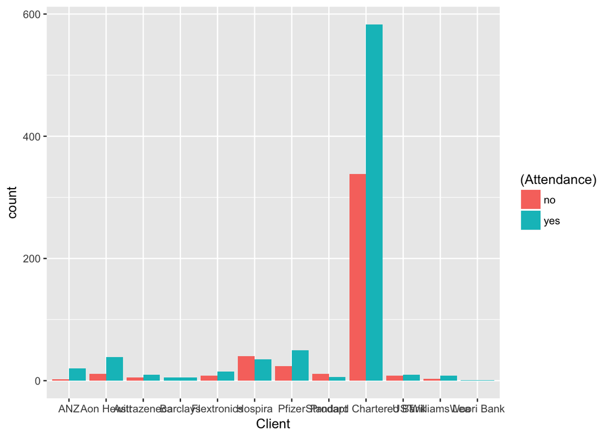

### Marital Status

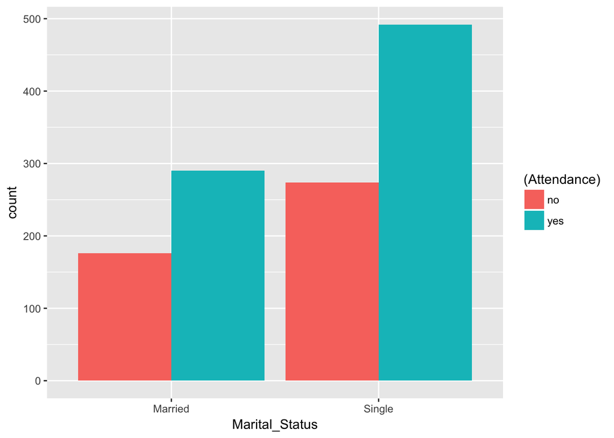

The date variable appears to be in many different formats. Lets use the package lubridate to see if we can parse these effectively.

# Day of Week

Lets create a day of week factor.

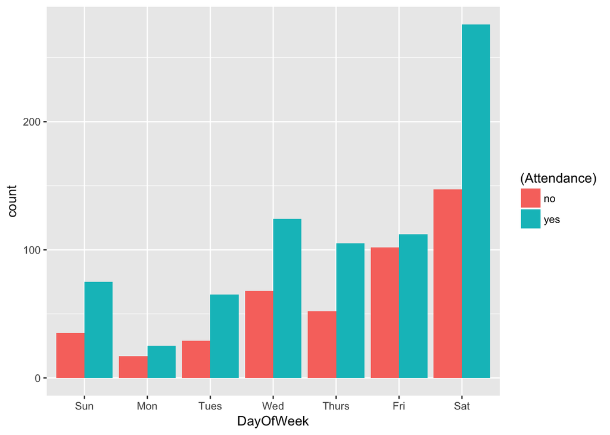

It is interesting to note that there are interviews on Saturday and Sunday. Also, there tend to be more interviews later in the week. Lastly, Friday has the worst attendance (makes sense).

# Skillsets

The skillset factor appears to have many different factors with similar names and also some factors that don’t appear to be skillsets.

# Decision Trees

```
##            Date          Client        Industry        Location
##               0               0               0               0
##        Position  Interview_Type          Gender   Candidate_Loc
##               0               0               0               0
##    Job_Location           Venue      Native_Loc      Permission
##               0               0               0               0
##            Hope     3_hour_call      Alt_Number Resume_Printout
##               0               0               0               0
##   Clarify_Venue    Share_Letter        Expected      Attendance
##               0               0               0               0
##  Marital_Status        Distance       DayOfWeek
##               0               0               0
```

```
##
##    no   yes
## 0.377 0.623
```

```
##
##        no       yes
## 0.3146552 0.6853448
```

```
##
## Call:
## C5.0.default(x = i_train[-20], y = i_train$Attendance, trials = 15)
##
## Classification Tree
## Number of samples: 1000
## Number of predictors: 22
##
## Number of boosting iterations: 15 requested;  7 used due to early stopping
## Average tree size: 3
##
## Non-standard options: attempt to group attributes
```

```
##
## Call:
## C5.0.default(x = i_train[-20], y = i_train$Attendance, trials = 15)
##
##
## C5.0 [Release 2.07 GPL Edition]      Mon Nov 27 21:12:44 2017
## -------------------------------
##
## Class specified by attribute `outcome'
##
## Read 1000 cases (23 attributes) from undefined.data
##
## -----  Trial 0:  -----
##
## Decision tree:
##
## Expected in {yes,uncertain}: yes (910/288)
## Expected = no: no (90/1)
##
## -----  Trial 1:  -----
##
## Decision tree:
##
## Expected = yes: yes (668.8/236.2)
## Expected in {no,uncertain}: no (331.2/98.4)
##
## -----  Trial 2:  -----
##
## Decision tree:
##
## Expected in {yes,uncertain}: yes (932/423.3)
## Expected = no: no (68/1.7)
##
## -----  Trial 3:  -----
##
## Decision tree:
##
## Expected = no: no (63.8/1.8)
## Expected in {yes,uncertain}:
## :...Interview_Type = scheduled: yes (237.3/92.7)
```

[output cut: 61 more lines]

```
##    ----  ----
##     113   264    (a): class no
##      20   603    (b): class yes
##
##
##  Attribute usage:
##
##  100.00% Expected
##   91.00% Interview_Type
##   91.00% Venue
##   89.90% Industry
##   66.00% Candidate_Loc
##
##
## Time: 0.0 secs
```

```
##
##
##    Cell Contents
## |-------------------------|
## |                       N |
## |         N / Table Total |
## |-------------------------|
##
##
## Total Observations in Table:  232
##
##
##                   | predicted Attendance
## actual Attendance |        no |       yes | Row Total |
## ------------------|-----------|-----------|-----------|
##                no |         5 |        68 |        73 |
##                   |     0.022 |     0.293 |           |
## ------------------|-----------|-----------|-----------|
##               yes |         3 |       156 |       159 |
##                   |     0.013 |     0.672 |           |
## ------------------|-----------|-----------|-----------|
##      Column Total |         8 |       224 |       232 |
## ------------------|-----------|-----------|-----------|
##
##
```

To potentially improve the model, we can include an error matrix.

```r
## Making some mistakes more costly than others
# create a cost matrix
error_cost <- matrix(c(0, 6, 1, 0), nrow = 2)
error_cost
```

```
##      [,1] [,2]
## [1,]    0    1
## [2,]    6    0
```

```r
# apply the cost matrix to the tree
interview_cost <- C5.0(i_train[-20], i_train$Attendance,
                          costs = error_cost, trials = 40)
interview_cost_pred <- predict(interview_cost, i_test)

CrossTable(i_test$Attendance, interview_cost_pred,
           prop.chisq = FALSE, prop.c = FALSE, prop.r = FALSE,
           dnn = c('actual attendance', 'predicted attendance'))
```

```
##
##
##    Cell Contents
## |-------------------------|
## |                       N |
## |         N / Table Total |
## |-------------------------|
##
##
## Total Observations in Table:  232
##
##
##                   | predicted attendance
## actual attendance |        no |       yes | Row Total |
## ------------------|-----------|-----------|-----------|
##                no |         7 |        66 |        73 |
##                   |     0.030 |     0.284 |           |
## ------------------|-----------|-----------|-----------|
##               yes |         6 |       153 |       159 |
##                   |     0.026 |     0.659 |           |
## ------------------|-----------|-----------|-----------|
##      Column Total |        13 |       219 |       232 |
## ------------------|-----------|-----------|-----------|
##
##
```

Lets see if one of the other ML algorithms preforms as well.

# SVM

```r
#  Training a model on the data
# begin by training a simple linear SVM
library(kernlab)
attendance_classifier <- ksvm(Attendance ~ ., data = i_train,
                          kernel = "vanilladot")
# look at basic information about the model
attendance_classifier
```

```
## Support Vector Machine object of class "ksvm"
##
## SV type: C-svc  (classification)
##  parameter : cost C = 1
##
## Linear (vanilla) kernel function.
##
## Number of Support Vectors : 661
##
## Objective Function Value : -536.6451
## Training error : 0.257
```

```r
## Step 3: Evaluating model performance
# predictions on testing dataset
#attendance_predictions <- predict(attendance_classifier, i_test)

#head(attendance_predictions)

#table(attendance_predictions, i_test$Attendance)
```

KNN

```
##
##
##    Cell Contents
## |-------------------------|
## |                       N |
## |           N / Row Total |
## |           N / Col Total |
## |         N / Table Total |
## |-------------------------|
##
##
## Total Observations in Table:  247
##
##
##               | att_pred
## i_test_labels |        no |       yes | Row Total |
## --------------|-----------|-----------|-----------|
##            no |         8 |        72 |        80 |
##               |     0.100 |     0.900 |     0.324 |
##               |     0.533 |     0.310 |           |
##               |     0.032 |     0.291 |           |
## --------------|-----------|-----------|-----------|
##           yes |         7 |       160 |       167 |
##               |     0.042 |     0.958 |     0.676 |
##               |     0.467 |     0.690 |           |
##               |     0.028 |     0.648 |           |
## --------------|-----------|-----------|-----------|
##  Column Total |        15 |       232 |       247 |
##               |     0.061 |     0.939 |           |
## --------------|-----------|-----------|-----------|
##
##
```